| title: “The pwrEWAS User’s Guide” |
| --- |
| author: “Stefan Graw, Devin C. Koestler” |
| date: “7 February 2019” |
| package: “pwrEWAS 0.99.0” |
| #bibliography: minfi.bib |
| abstract: > |
| pwrEWAS is a user-friendly tool to estimate power in EWAS as a function of sample and effect size |
| for two-group comparisons of DNAm (e.g., case vs control, exposed vs non-exposed, etc.). Detailed description |
| of in-/outputs, instructions and an example, as well as interpretations of the example results are provided in |
| the following vignette. |
| vignette: > |
| % |
| % |
| % |
| output: |
| BiocStyle::pdf_document: |
| keep_tex: true |
| number_sections: false |

# Introduction

When designing an epigenome-wide association study (EWAS) to investigate the relationship be-tween DNA methylation (DNAm) and some exposure(s) or phenotype(s), it is critically important to assess the sample size needed to detect a hypothesized difference with adequate statistical power. However, the complex and nuanced nature of DNAm data make direct assessment of statistical power challenging. To circumvent these challenges and to address outstanding need for a user-friendly interface for EWAS power evaluation, we have developed pwrEWAS. The current imple-mentation of pwrEWAS accommodates power estimation for two-group comparisons of DNAm (e.g., case vs control, exposed vs non-exposed, etc.). Power is calculated by means of a Monte Carlo approach in which DNAm data are randomly generated from one of several different existing data datasets, chosen to cover the most common tissue-types used in EWAS. In addition to specify-ing the tissue type to be used for DNAm profiling, users are required to specify the sample size, number of differentially methylated CpGs, effect size(s) (e.g., $\Delta_\beta$), target false discovery rate (FDR) and the number of simulated data sets, and have the option of selecting from several different sta-tistical methods to perform differential methylation analyses. pwrEWAS reports the marginal power, marginal type I error rate, marginal FDR, and false discovery cost (FDC) .The R-Shiny web inter-face allows for easy input of user-defined parameters and includes an advanced settings button that offers additional options pertaining to data generation and computation.

## Dependencies

pwrEWAS requires the following dependencies:

`r library(doParallel) library(abind) library(truncnorm) library(shiny) library(ggplot2) library(parallel) library(shinyWidgets) library(BiocManager) library(shinyBS) library(foreach) library(devtools)`

## Installation pwrEWAS can be installed from guthub with the following R code:

`r devtools::install_github("stefangraw/pwrEWAS") library(pwrEWAS)`

# Usage

To execute the main pwrEWAS function one of the following to codes can be used. pwrEWAS allows the user to specify the effect size in one of two ways, by either providing a target maximal difference in methylation (“targetDelta”), or by providing the standard deviation of the simulated differnces (“deltaSD”). Only one of both arguments can be provided. If “targetDelta” is specified, pwrEWAS will automatically identify a standard deviation to simulate differences in methylation, such that the 99.99th percentile of the absolute value of simulated differences falls within a range around the targeted maximal difference in DNAm (see paper for additional details). If “deltaSD” is specified, pwrEWAS will simulate differences in methylation using the provided standard deviation. The results can be visualized by using two function provided in pwrEWAS: “pwrEWAS_powerPlot” and “pwrEWAS_deltaDensity”

```r
# providing the targeted maximal difference in DNAm
results_targetDelta = pwrEWAS(minTotSampleSize = 10,
                              maxTotSampleSize = 50,
                              SampleSizeSteps = 10,
                              NcntPer = 0.5,
                              targetDelta = c(0.2, 0.5),
                              J = 100,
                              targetDmCpGs = 10,
                              tissueType = "Adult (PBMC)",
                              detectionLimit = 0.01,
                              DMmethod = "limma",
                              FDRcritVal = 0.05,
                              core = 4,
                              sims = 50)

# providing the targeted maximal difference in DNAm
results_deltaSD = pwrEWAS(minTotSampleSize = 10,
                          maxTotSampleSize = 50,
                          SampleSizeSteps = 10,
                          NcntPer = 0.5,
                          deltaSD = c(0.02, 0.05),
                          J = 100,
                          targetDmCpGs = 10,
                          tissueType = "Adult (PBMC)",
                          detectionLimit = 0.01,
                          DMmethod = "limma",
                          FDRcritVal = 0.05,
                          core = 4,
                          sims = 50)

pwrEWAS_powerPlot(out$powerArray, sd = FALSE)
pwrEWAS_deltaDensity(out$deltaArray, detectionLimit = 0.01, sd = FALSE)
```

## Input parameter

The following table provides a description of the input arguments:

| Parameter | Decription |
| --- | --- |
| minTotSampleSize | Lowest total sample sizes to be considered |
| maxTotSampleSize | Highest total sample sizes to be considered |
| SampleSizeSteps | Steps with which total sample size increases from minTotSampleSize to maxTotSampleSize |
| NcntPer | Rate by which the total sample size is split into groups (0.5 corresponds to a balanced study; rate for group 2 is equal to 1 rate of group 1) |
| targetDelta | Standard deviations of the simulated differences is automatically determined such that the 99%til of the simulated differences are within a range around the provided values |
| deltaSD | Differences in methylation will be simulated using provided standard deviation |
| J | Number of CpG site that will simulated and tested (increasing Number of CpGs tested will require increasing RAM (memory)) |
| targetDmCpGs | Target number of CpGs simulated with meaningful differences (differences greater than detection limit) |
| tissueType | Heterogeneity of different tissue types can have effects on the results. Please select your tissue type of interest or one you believe is the closest |
| detectionLimit | Limit to detect changes in methylation. Simulated differences below the detection limit will not be consider as meaningful differentially methylated CpGs |
| DMmethod | Method used to perform differential methylation analysis |
| FDRcritVal | Critical value to control the False Discovery Rate (FDR) using the Benjamini and Hochberg method |
| core | Number of cores used to run multiple threads. Ideally, the number of different total samples sizes multiplied by the number of effect sizes should be a multiple (m) of the number of cores (#sampleSize… |
| sims | Number of repeated simulation/simulated data sets under the same conditions for consistent results |

## Output parameter

Running pwrEWAS will result in an object with the following four attributes: meanPower, powerArray, deltaArray, and metric. The first attribute, meanPower, is a 2D matrix with empirically estimated marginal mean power for sample sizes and target $\Delta_\beta$’s (averaged over simulated data sets). The second attribute, powerArray, provides the full set of empirically estimated marginal power for sample sizes, target $\Delta_\beta$’s, and simulated data sets in a 3D matrix. The third attribute, deltaArray, contains a 3D matrix with simulated $\Delta_\beta$’s for sample sizes, target $\Delta_\beta$, and simulated data sets. The last attribute “metric” contains 2D matrices with the marginal type I error rate (marTypeI), power in the classical sense (classicalPower), actual FDR (FDR), and False Discovery Cost (FDC), in table format, where sample sizes are shown as rows and effect sizes are columns.

# Runtime

| Total sample size Effect size $\Delta_\beta$ | 0.1 | 0.1, 0.2 | 0.1, 0.3, 0.5 |
| --- | --- | --- | --- |
| 10 | 2min 21sec | 3min 11sec | 3min 50sec |
| 100 | 6min 22sec | 7min 39sec | 8min 33sec |
| 500 | 24min 43sec | 27min 36sec | 29min 22sec |
| 10-100 (increments of 10) | 9min 40sec | 16min 34sec | 23min 44sec |
| 300-500 (increments of 100) | 27min 58sec | 30min 01sec | 52min 00sec |

# Example

## Running pwrEWAS

Running pwrEWAS and providing target maximal difference in methylation:

```r
set.seed(1234)
results_targetDelta = pwrEWAS(minTotSampleSize = 20,
                              maxTotSampleSize = 20, #220
                              SampleSizeSteps = 20,
                              NcntPer = 0.5,
                              targetDelta = c(0.1, 0.2, 0.4),
                              J = 100, #100000
                              targetDmCpGs = 10, # 100
                              tissueType = "Adult (PBMC)",
                              detectionLimit = 0.01,
                              DMmethod = "limma",
                              FDRcritVal = 0.05,
                              core = 6,
                              sims = 50)
```

```
## [2019-02-07 15:22:03] Finding tau...done [2019-02-07 15:22:04]
## [1] "The following taus were chosen: 0.0390625, 0.07421875, 0.15234375"
## [2019-02-07 15:22:04] Running simulation ...done [2019-02-07 15:22:16]
```

When running pwrEWAS, first $\tau$ will be determined. The beginning and finish of this process willl be printed with time stamps (“[time stamp] Finding tau…done [time stamp]”). Next, pwrEWAS will run the simulations to empirically estimate power. Likewise, the beginning and finish of this procress will be printed with time stamps: “[time stamp] Running simulation …done [time stamp]”.

Running pwrEWAS and providing standard deviation of difference in methylation:

```r
set.seed(1234)
results_deltaSD = pwrEWAS(minTotSampleSize = 20,
                          maxTotSampleSize = 20, #220
                          SampleSizeSteps = 20,
                          NcntPer = 0.5,
                          deltaSD = c(0.027, 0.055, 0.109),
                          J = 100, #100000
                          targetDmCpGs = 10, # 100
                          tissueType = "Adult (PBMC)",
                          detectionLimit = 0.01,
                          DMmethod = "limma",
                          FDRcritVal = 0.05,
                          core = 6,
                          sims = 50)
```

```
## [2019-02-07 15:22:18] Running simulation ...done [2019-02-07 15:22:30]
```

Running pwrEWAS will result in an object, that stores the following four attributes:

```r
str(results_targetDelta)
```

```
## List of 4
##  $ meanPower : num [1, 1:3] 0.565 0.723 0.843
##   ..- attr(*, "dimnames")=List of 2
##   .. ..$ : chr "20"
##   .. ..$ : chr [1:3] "0.1" "0.2" "0.4"
##  $ powerArray: num [1:50, 1, 1:3] 0.769 0.273 0.385 0.545 0.6 ...
##   ..- attr(*, "dimnames")=List of 3
##   .. ..$ : chr [1:50] "1" "2" "3" "4" ...
##   .. ..$ : chr "20"
##   .. ..$ : chr [1:3] "0.1" "0.2" "0.4"
##  $ deltaArray:List of 3
##   ..$ 0.1: num [1:650, 1] -0.0457 0.0283 0.0439 0.0133 -0.0727 ...
##   .. ..- attr(*, "dimnames")=List of 2
##   .. .. ..$ : NULL
##   .. .. ..$ : chr "20"
##   ..$ 0.2: num [1:600, 1] 0.0141 0.0251 -0.1222 -0.1565 -0.0267 ...
##   .. ..- attr(*, "dimnames")=List of 2
##   .. .. ..$ : NULL
##   .. .. ..$ : chr "20"
##   ..$ 0.4: num [1:550, 1] 0.0203 0.0662 -0.0228 0.2418 0.0117 ...
##   .. ..- attr(*, "dimnames")=List of 2
##   .. .. ..$ : NULL
##   .. .. ..$ : chr "20"
##  $ metric    :List of 5
##   ..$ marTypeI      : num [1, 1:3] 0.00391 0.005 0.00539
##   .. ..- attr(*, "dimnames")=List of 2
##   .. .. ..$ : chr "20"
##   .. .. ..$ : chr [1:3] "0.1" "0.2" "0.4"
##   ..$ classicalPower: num [1, 1:3] 0.469 0.637 0.8
##   .. ..- attr(*, "dimnames")=List of 2
##   .. .. ..$ : chr "20"
##   .. .. ..$ : chr [1:3] "0.1" "0.2" "0.4"
##   ..$ FDR           : num [1, 1:3] 0.0455 0.0485 0.0458
##   .. ..- attr(*, "dimnames")=List of 2
##   .. .. ..$ : chr "20"
##   .. .. ..$ : chr [1:3] "0.1" "0.2" "0.4"
##   ..$ FDC           : num [1, 1:3] 0.0563 0.0591 0.0566
##   .. ..- attr(*, "dimnames")=List of 2
##   .. .. ..$ : chr "20"
##   .. .. ..$ : chr [1:3] "0.1" "0.2" "0.4"
##   ..$ probTP        : num [1, 1:3] 1 1 1
##   .. ..- attr(*, "dimnames")=List of 2
##   .. .. ..$ : chr "20"
##   .. .. ..$ : chr [1:3] "0.1" "0.2" "0.4"
```

```r
str(results_deltaSD)
```

```
## List of 4
##  $ meanPower : num [1, 1:3] 0.526 0.666 0.772
##   ..- attr(*, "dimnames")=List of 2
##   .. ..$ : chr "20"
##   .. ..$ : chr [1:3] "0.027" "0.055" "0.109"
##  $ powerArray: num [1:50, 1, 1:3] 0.286 0.375 0.4 0.143 0.571 ...
##   ..- attr(*, "dimnames")=List of 3
##   .. ..$ : chr [1:50] "1" "2" "3" "4" ...
##   .. ..$ : chr "20"
##   .. ..$ : chr [1:3] "0.027" "0.055" "0.109"
##  $ deltaArray:List of 3
##   ..$ 0.027: num [1:600, 1] 0.0339 -0.00584 0.01516 -0.02836 -0.02199 ...
##   .. ..- attr(*, "dimnames")=List of 2
##   .. .. ..$ : NULL
##   .. .. ..$ : chr "20"
##   ..$ 0.055: num [1:600, 1] -0.0799 -0.0611 0.0179 0.0446 0.0621 ...
##   .. ..- attr(*, "dimnames")=List of 2
##   .. .. ..$ : NULL
##   .. .. ..$ : chr "20"
##   ..$ 0.109: num [1:600, 1] 0.0259 0.13 0.0404 0.1208 0.0187 ...
##   .. ..- attr(*, "dimnames")=List of 2
##   .. .. ..$ : NULL
##   .. .. ..$ : chr "20"
##  $ metric    :List of 5
##   ..$ marTypeI      : num [1, 1:3] 0.00386 0.00295 0.00341
##   .. ..- attr(*, "dimnames")=List of 2
##   .. .. ..$ : chr "20"
##   .. .. ..$ : chr [1:3] "0.027" "0.055" "0.109"
##   ..$ classicalPower: num [1, 1:3] 0.372 0.595 0.708
##   .. ..- attr(*, "dimnames")=List of 2
##   .. .. ..$ : chr "20"
##   .. .. ..$ : chr [1:3] "0.027" "0.055" "0.109"
##   ..$ FDR           : num [1, 1:3] 0.0636 0.0297 0.0322
##   .. ..- attr(*, "dimnames")=List of 2
##   .. .. ..$ : chr "20"
##   .. .. ..$ : chr [1:3] "0.027" "0.055" "0.109"
##   ..$ FDC           : num [1, 1:3] 0.1099 0.0394 0.0379
##   .. ..- attr(*, "dimnames")=List of 2
##   .. .. ..$ : chr "20"
##   .. .. ..$ : chr [1:3] "0.027" "0.055" "0.109"
##   ..$ probTP        : num [1, 1:3] 0.98 1 1
##   .. ..- attr(*, "dimnames")=List of 2
##   .. .. ..$ : chr "20"
##   .. .. ..$ : chr [1:3] "0.027" "0.055" "0.109"
```

```r
dim(results_targetDelta$meanPower)
```

```
## [1] 1 3
```

```r
print(results_targetDelta$meanPower)
```

```
##          0.1       0.2       0.4
## 20 0.5653771 0.7234877 0.8428434
```

```r
dim(results_deltaSD$meanPower)
```

```
## [1] 1 3
```

```r
print(results_deltaSD$meanPower)
```

```
##        0.027     0.055     0.109
## 20 0.5257698 0.6660859 0.7722929
```

The attribute “powerArray” should primarily be to create a power plot, but can also be used to investigate the power results for the individual simulations. In pwrEWAS included is a function “pwrEWAS_powerPlot”, that will create a power plot, where power (y-axis) is shown as a function of sample sizes (x-axis) for different effect sizes (seperate colored lines). For each sample size, the mean power as well as the 95%tile interval (2.5% and 97.5%) is shown.

```r
dim(results_targetDelta$powerArray) # simulations x sample sizes x effect sizes
```

```
## [1] 50  1  3
```

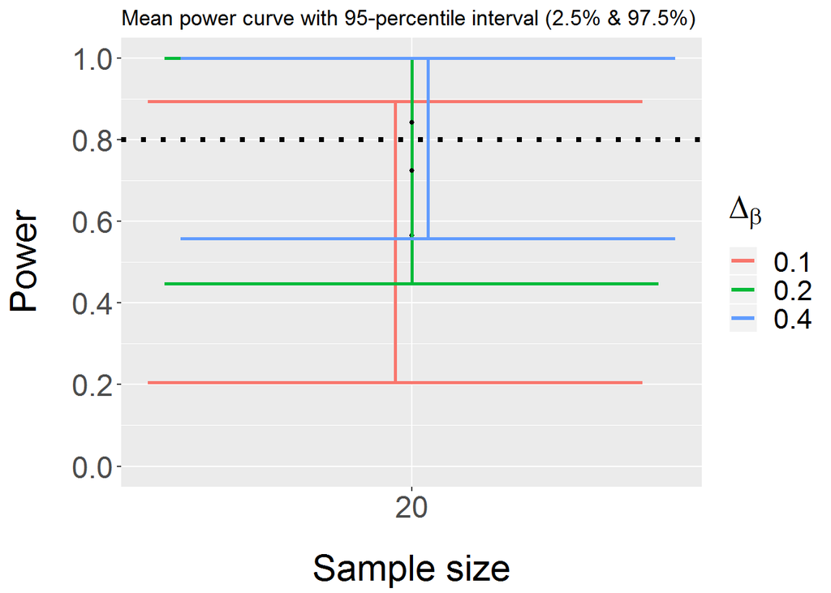

```r
pwrEWAS_powerPlot(results_targetDelta$powerArray, sd = FALSE)
```

```r
dim(results_deltaSD$powerArray) # simulations x sample sizes x effect sizes
```

```
## [1] 50  1  3
```

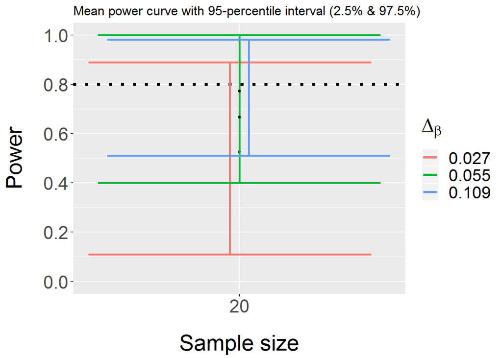

```r
pwrEWAS_powerPlot(results_deltaSD$powerArray, sd = FALSE)
```

```r
# maximum value of simulated differences by target value
lapply(results_targetDelta$deltaArray, max)
```

```
## $`0.1`
## [1] 0.1316195
##
## $`0.2`
## [1] 0.2290076
##
## $`0.4`
## [1] 0.3879471
```

```r
lapply(results_deltaSD$deltaArray, max)
```

```
## $`0.027`
## [1] 0.07386039
##
## $`0.055`
## [1] 0.1495121
##
## $`0.109`
## [1] 0.3855895
```

```r
# percentage of simulated differences to be within the target range
mean(results_targetDelta$deltaArray[[1]] < 0.1)
```

```
## [1] 0.9923077
```

```r
mean(results_targetDelta$deltaArray[[2]] < 0.2)
```

```
## [1] 0.9966667
```

```r
mean(results_targetDelta$deltaArray[[3]] < 0.4)
```

```
## [1] 1
```

```r
mean(results_deltaSD$deltaArray[[1]] < 0.1)
```

```
## [1] 1
```

```r
mean(results_deltaSD$deltaArray[[2]] < 0.2)
```

```
## [1] 1
```

```r
mean(results_deltaSD$deltaArray[[3]] < 0.4)
```

```
## [1] 1
```

To get a better understanding of how the differences in mean DNAm look like, pwrEWAS provides a density plot, where the distribution of siumlated differences in mean DNAm is plotted by target differences in DNAm ($\Delta_\beta$). The color theme matches the colors of the power plot. Simulated differences within the detection limit around zero are removed, as they are here not defined as real/meaningful differences.

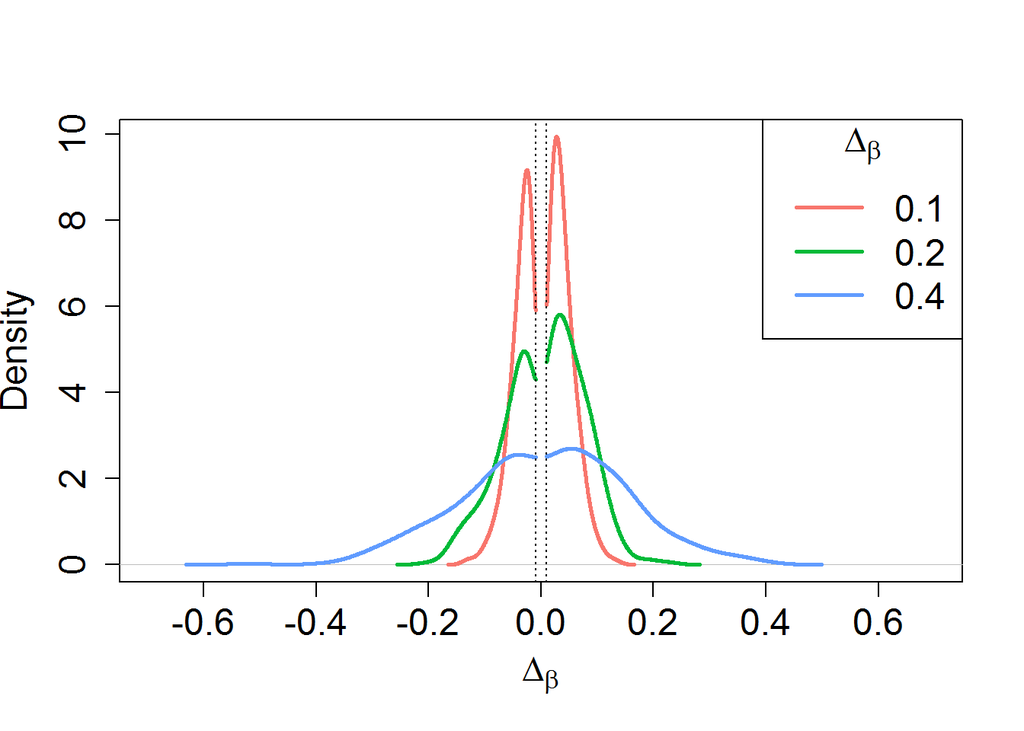

```r
pwrEWAS_deltaDensity(results_targetDelta$deltaArray, detectionLimit = 0.01, sd = FALSE)
```

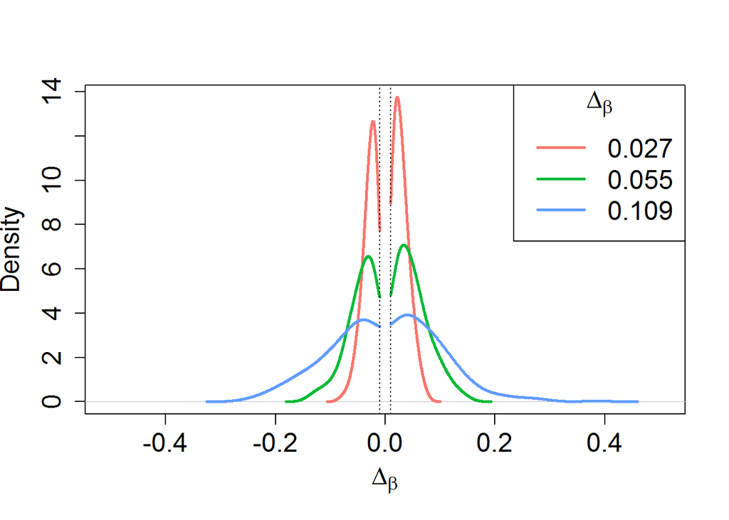

```r
pwrEWAS_deltaDensity(results_deltaSD$deltaArray, detectionLimit = 0.01, sd = FALSE)
```

```r
results_targetDelta$metric
```

```
## $marTypeI
##            0.1   0.2         0.4
## 20 0.003908046 0.005 0.005393258
##
## $classicalPower
##          0.1       0.2 0.4
## 20 0.4692308 0.6366667 0.8
##
## $FDR
##           0.1        0.2        0.4
## 20 0.04554113 0.04848651 0.04577894
##
## $FDC
##           0.1        0.2        0.4
## 20 0.05634921 0.05907215 0.05659019
##
## $probTP
##    0.1 0.2 0.4
## 20   1   1   1
```

```r
results_deltaSD$metric
```

```
## $marTypeI
##          0.027       0.055       0.109
## 20 0.003863636 0.002954545 0.003409091
##
## $classicalPower
##        0.027 0.055     0.109
## 20 0.3716667 0.595 0.7083333
##
## $FDR
##         0.027      0.055      0.109
## 20 0.06359524 0.02971429 0.03218398
##
## $FDC
##        0.027      0.055      0.109
## 20 0.1098882 0.03935714 0.03786724
##
## $probTP
##    0.027 0.055 0.109
## 20  0.98     1     1
```

# SessionInfo

```r
toLatex(sessionInfo())
```

[output not shown]